# Test Open Field Analysis

Alexa & Viktoria & Adam

December 10th, 2018

## Preparation

Set parameters

Load libraries

```r
# tidyverse includes the packages readr, dplyr, ggplot2 ... etc.
library(tidyverse)

# ggbeeswarm includes geom_beeswarm()
library(ggbeeswarm)

# broom includes tidy()
library(broom)
```

## Read in the raw data

Read in the open field test raw data (**Analysis Output-AV Open Field.csv**):

```r
# Import open field data
openFieldDataRaw <- read_csv("Analysis Output-AV Open Field.csv", skip = 4,
                            col_names = header, na = c("", "NA", "-"))

# Take a look at the raw open field data
openFieldDataRaw
```

```
## # A tibble: 20 x 10
##    `Trial #` `In Border:Peri~ `In Border:Peri~ `In Border:Peri~
##        <dbl>            <dbl>            <dbl>            <dbl>
##  1         1             599.                1           1.27
##  2         2             563.               15           0
##  3         3             581.               14           0.267
##  4         4             594.                7           0.534
##  5         5             553.               13           0
##  6         6             593.                4           0.334
##  7         7             566.               24           0
##  8         8             598.                4           0
##  9         9             576.               13           0
## 10        10             590.                4           0
## 11        11             586.                6           5.47
## 12        12             584.               13           0
## 13        13             567.               25           0.0667
## 14        14             587.               13           0
## 15        15             585.                9           0
## 16        16             577.               13           0
## 17        17             597.                4           0.334
## 18        18             566.               23           1.40
## 19        19             596.                5           0
## 20        20             588.               11           0
## # ... with 6 more variables: `In Center:Center:Duration` <dbl>, `In
## #   Center:Center:Frequency` <dbl>, `In Center:Center:Latency to
## #   first` <dbl>, `In Zone:Center/Center-point:Duration` <dbl>, `In
## #   Zone:Center/Center-point:Frequency` <dbl>, `In
## #   Zone:Center/Center-point:Latency to first` <dbl>
```

Read in the data containing the treatment and sex information for each animal (**Injections Data.csv**):

```r
# Import injections data
injectionsDataRaw <- read_csv("Injections Data.csv", n_max = 20)

# Take a look at the injections data
injectionsDataRaw
```

```
## # A tibble: 20 x 29
##    Treatment Sex   Tag   `12-Oct` `13-Oct` `14-Oct` `15-Oct` `16-Oct`
##        <dbl> <chr> <chr>    <dbl>    <dbl>    <dbl>    <dbl>    <dbl>
##  1         0 F     1L          25       27       31       34       36
##  2         1 M     2L          27       29       33       37       36
##  3         0 M     3L          25       27       31       33       34
##  4         1 F     1R          23       24       28       30       33
##  5         0 M     2R          25       27       31       34       35
##  6         1 F     3R          21       23       25       27       30
##  7         0 M     1L-1R       27       30       34       36       37
##  8         1 M     1L-2R       28       29       32       36       38
##  9         0 F     2L-2R       26       27       31       33       35
## 10         1 F     2L-1R       27       28       31       34       36
## 11         0 F     1L          21       25       27       31       32
## 12         1 F     2L          23       25       28       30       33
## 13         0 M     3L          23       27       30       32       36
## 14         1 M     1R          24       26       28       32       34
## 15         0 M     2L-1R       23       26       28       31       33
## 16         1 M     3R          24       27       30       33       36
## 17         0 M     1L-1R       25       27       30       33       35
## 18         1 F     1L-2R       22       25       27       30       32
## 19         0 F     2L-2R       23       26       29       31       35
## 20         1 F     2R          23       26       29       30       33
## # ... with 21 more variables: `17-Oct` <dbl>, `18-Oct` <dbl>,
## #   `19-Oct` <dbl>, `20-Oct` <dbl>, `21-Oct` <dbl>, `22-Oct` <dbl>,
## #   `23-Oct` <dbl>, `24-Oct` <dbl>, `25-Oct` <dbl>, `26-Oct` <dbl>,
## #   `27-Oct` <dbl>, `28-Oct` <dbl>, `29-Oct` <dbl>, `30-Oct` <dbl>,
## #   `31-Oct` <dbl>, `Parent Cage #` <dbl>, `Current Cage #` <dbl>, `Trial
## #   # Open Field` <dbl>, `Trial # Familiar Object` <dbl>, `Trial # Novel
## #   Object` <dbl>, Comments <chr>
```

Read in a table that maps treatment numbers to treatment strings

```r
# Create a dictionary for Treatment
treatmentTypeTable <- read_csv("Treatment Dictionary.csv")

# Display the table
treatmentTypeTable
```

```
## # A tibble: 2 x 2
##   Treatment TreatmentStr
##       <dbl> <chr>
## 1         0 Control
## 2         1 Ethosuximide
```

```r
# OLD CODE:
# treatmentTypeTable <-
#     tibble(Treatment = 0:1, TreatmentStr = c("Control", "Ethosuximide"))
```

## Combine and rearrange the data

Starting from the open field raw data, do the following:  
1. Add the treatment and sex information by matching up the trial number  
2. Add the treatment string be matching up the treatment number  
3. Choose the column corresponding to duration in center and rename it  
4. Choose the column corresponding to duration in border and rename it  
5. Make “Sex”" a categorical variable  
6. Make “TreatmentStr” a categorical variable  
7. Create a new column for the ratio of duration in border to duration in center

```r
# Rearrange the data
openFieldDataExpanded <-
    openFieldDataRaw %>%
    full_join(injectionsDataRaw, by = c("Trial #" = "Trial # Open Field")) %>%
    full_join(treatmentTypeTable, by = "Treatment") %>%
    mutate(DurationInCenter = `In Zone:Center/Center-point:Duration`) %>%
    mutate(DurationInBorder = `In Border:Periphery/Center-point:Duration`) %>%
    mutate(Sex = factor(Sex)) %>%
    mutate(TreatmentStr = factor(TreatmentStr)) %>%
    mutate(DurationRatio = DurationInBorder / DurationInCenter)

# Take a glimpse of all the variables in the data
glimpse(openFieldDataExpanded)
```

```
## Observations: 20
## Variables: 42
## $ `Trial #`                                           <dbl> 1, 2, 3, 4...
## $ `In Border:Periphery/Center-point:Duration`         <dbl> 598.7988, ...
## $ `In Border:Periphery/Center-point:Frequency`        <dbl> 1, 15, 14,...
## $ `In Border:Periphery/Center-point:Latency to first` <dbl> 1.267934, ...
## $ `In Center:Center:Duration`                         <dbl> NA, 57.123...
## $ `In Center:Center:Frequency`                        <dbl> 0, 27, 24,...
## $ `In Center:Center:Latency to first`                 <dbl> NA, 88.755...
## $ `In Zone:Center/Center-point:Duration`              <dbl> NA, 37.103...
## $ `In Zone:Center/Center-point:Frequency`             <dbl> 0, 15, 13,...
## $ `In Zone:Center/Center-point:Latency to first`      <dbl> NA, 89.289...
## $ Treatment                                           <dbl> 0, 0, 1, 0...
## $ Sex                                                 <fct> F, F, F, M...
## $ Tag                                                 <chr> "2L-2R", "...
```

[output cut: 29 more lines]

Remove the first animal because it was used as a test animal

```r
# Select all but the first row
openFieldDataFiltered <-
    openFieldDataExpanded %>%
    slice(2:n())

# Take a look at the data with rows filtered
openFieldDataFiltered
```

```
## # A tibble: 19 x 42
##    `Trial #` `In Border:Peri~ `In Border:Peri~ `In Border:Peri~
##        <dbl>            <dbl>            <dbl>            <dbl>
##  1         2             563.               15           0
##  2         3             581.               14           0.267
##  3         4             594.                7           0.534
##  4         5             553.               13           0
##  5         6             593.                4           0.334
##  6         7             566.               24           0
##  7         8             598.                4           0
##  8         9             576.               13           0
##  9        10             590.                4           0
## 10        11             586.                6           5.47
## 11        12             584.               13           0
## 12        13             567.               25           0.0667
## 13        14             587.               13           0
## 14        15             585.                9           0
## 15        16             577.               13           0
## 16        17             597.                4           0.334
## 17        18             566.               23           1.40
## 18        19             596.                5           0
## 19        20             588.               11           0
## # ... with 38 more variables: `In Center:Center:Duration` <dbl>, `In
## #   Center:Center:Frequency` <dbl>, `In Center:Center:Latency to
## #   first` <dbl>, `In Zone:Center/Center-point:Duration` <dbl>, `In
## #   Zone:Center/Center-point:Frequency` <dbl>, `In
## #   Zone:Center/Center-point:Latency to first` <dbl>, Treatment <dbl>,
## #   Sex <fct>, Tag <chr>, `12-Oct` <dbl>, `13-Oct` <dbl>, `14-Oct` <dbl>,
## #   `15-Oct` <dbl>, `16-Oct` <dbl>, `17-Oct` <dbl>, `18-Oct` <dbl>,
## #   `19-Oct` <dbl>, `20-Oct` <dbl>, `21-Oct` <dbl>, `22-Oct` <dbl>,
## #   `23-Oct` <dbl>, `24-Oct` <dbl>, `25-Oct` <dbl>, `26-Oct` <dbl>,
## #   `27-Oct` <dbl>, `28-Oct` <dbl>, `29-Oct` <dbl>, `30-Oct` <dbl>,
## #   `31-Oct` <dbl>, `Parent Cage #` <dbl>, `Current Cage #` <dbl>, `Trial
## #   # Familiar Object` <dbl>, `Trial # Novel Object` <dbl>,
## #   Comments <chr>, TreatmentStr <fct>, DurationInCenter <dbl>,
## #   DurationInBorder <dbl>, DurationRatio <dbl>
```

Select variables that will be analyzed

```r
# Select variables that will be analyzed
openFieldData <-
    openFieldDataFiltered %>%
    select(`Trial #`, Treatment = TreatmentStr, Sex,
           DurationInCenter, DurationInBorder, DurationRatio)

# Take a look at the data with columns filtered
openFieldData
```

```
## # A tibble: 19 x 6
##    `Trial #` Treatment Sex   DurationInCenter DurationInBorder
##        <dbl> <fct>     <fct>            <dbl>            <dbl>
##  1         2 Control   F                37.1              563.
##  2         3 Ethosuxi~ F                18.4              581.
##  3         4 Control   M                 5.34             594.
##  4         5 Control   M                47.5              553.
##  5         6 Ethosuxi~ F                 7.21             593.
##  6         7 Ethosuxi~ F                34.0              566.
##  7         8 Ethosuxi~ M                 2.20             598.
##  8         9 Ethosuxi~ M                24.5              576.
##  9        10 Control   M                 9.81             590.
## 10        11 Ethosuxi~ F                 8.94             586.
## 11        12 Ethosuxi~ F                16.3              584.
## 12        13 Control   M                32.8              567.
## 13        14 Control   M                13.1              587.
## 14        15 Ethosuxi~ M                15.0              585.
## 15        16 Ethosuxi~ M                22.8              577.
## 16        17 Control   M                 2.80             597.
## 17        18 Control   F                32.6              566.
## 18        19 Ethosuxi~ F                 3.74             596.
## 19        20 Control   F                12.5              588.
## # ... with 1 more variable: DurationRatio <dbl>
```

## Make plots

#### Use Duration in Center

Plot the Duration in Center versus Treatment as a box plot

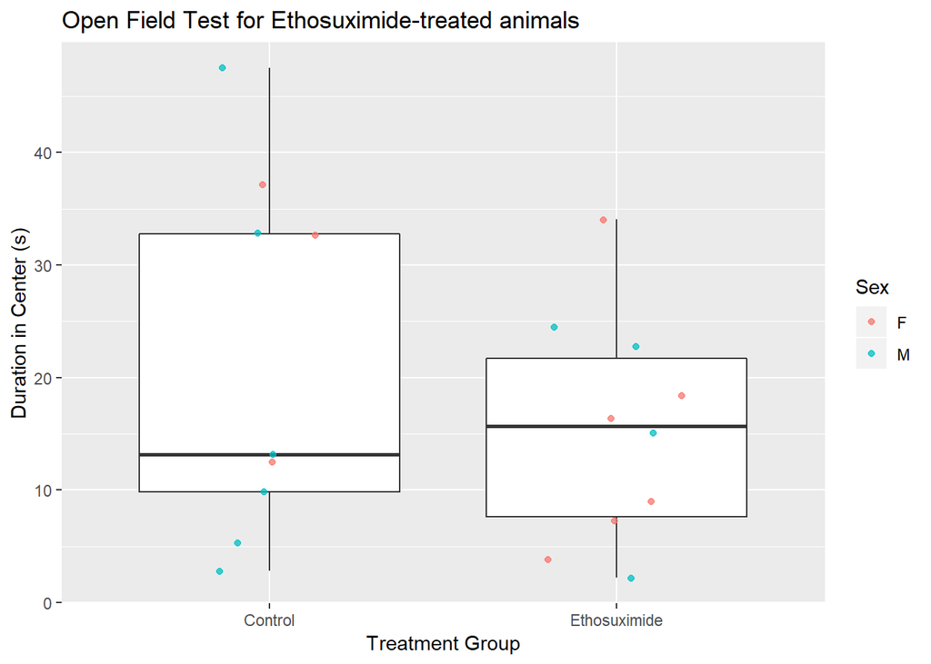

```r
# Add the data to the canvas
durationPlot <- ggplot(openFieldData, aes(Treatment, DurationInCenter)) +
    xlab("Treatment Group") + ylab("Duration in Center (s)") +
    ggtitle("Open Field Test for Ethosuximide-treated animals")

# Plot as a combination of jitter and box plot
durationPlot + geom_boxplot(outlier.alpha = 0) +
    geom_jitter(aes(color = Sex), alpha = 0.75, width = 0.2)
```

```r
# Save the plot
ggsave("openField_durationCenter_boxplot_jitter.png")
```

Plot the Duration in Center versus Treatment as a violin plot

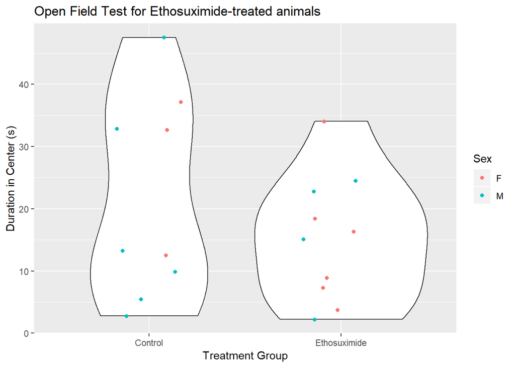

```r
# Plot as a combination of jitter and violin plot
durationPlot + geom_violin() +
    geom_jitter(aes(color = Sex), width = 0.2)
```

```r
# Save the plot
ggsave("openField_durationCenter_violin_jitter.png")
```

Plot the Duration in Center versus Treatment as a beeswarm plot

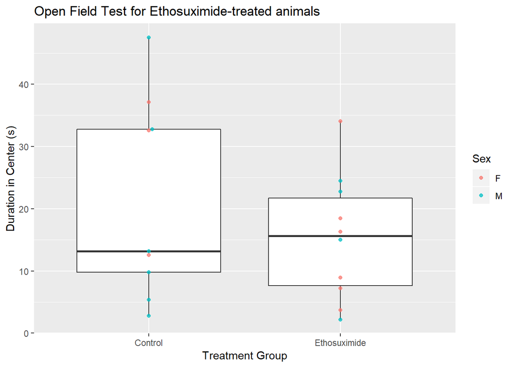

```r
# Plot as a combination of box and beeswarm plot
durationPlot + geom_boxplot(outlier.alpha = 0) +
    geom_beeswarm(aes(color = Sex), alpha = 0.75)
```

```r
# Save the plot
ggsave("openField_durationCenter_boxplot_beeswarm.png")
```

#### Use Ratio of Duration in Border to Duration in Center

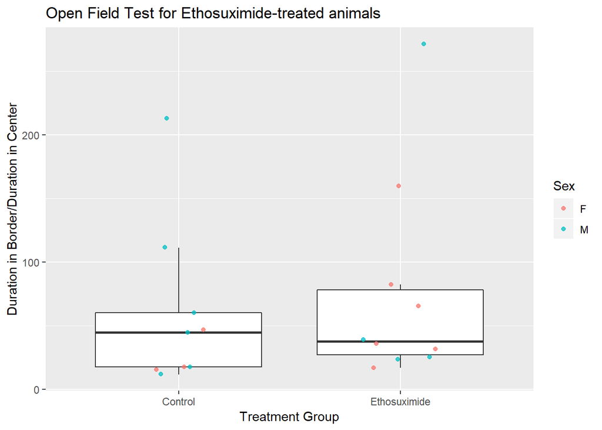

```r
# Add the data to the canvas
DurationRatioPlot <- ggplot(openFieldData, aes(Treatment, DurationRatio)) +
    xlab("Treatment Group") + ylab("Duration in Border/Duration in Center") +
    ggtitle("Open Field Test for Ethosuximide-treated animals")

# Plot as a combination of jitter and box plot
DurationRatioPlot + geom_boxplot(outlier.alpha = 0) +
    geom_jitter(aes(color = Sex), alpha = 0.75, width = 0.2)
```

```r
# Save the plot
ggsave("openField_DurationRatio_boxplot_jitter.png")
```

Plot the Ratio of Duration in Border to Duration in Center as a violin plot

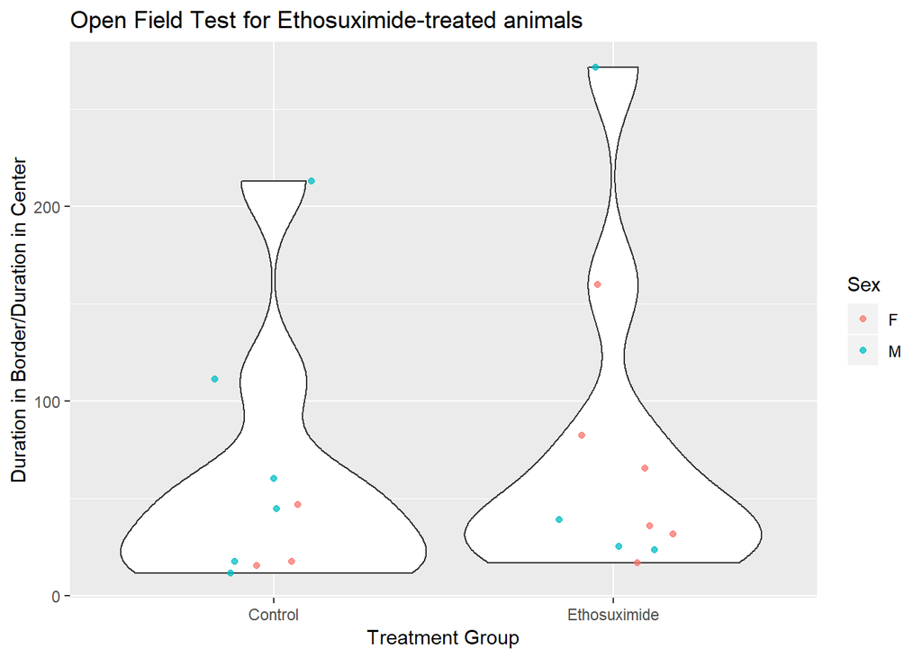

```r
# Plot as a combination of jitter and violin plot
DurationRatioPlot + geom_violin() +
    geom_jitter(aes(color = Sex), alpha = 0.75, width = 0.2)
```

```r
# Save the plot
ggsave("openField_DurationRatio_violin_jitter.png")
```

Plot the Ratio of Duration in Border to Duration in Center as a beeswarm plot

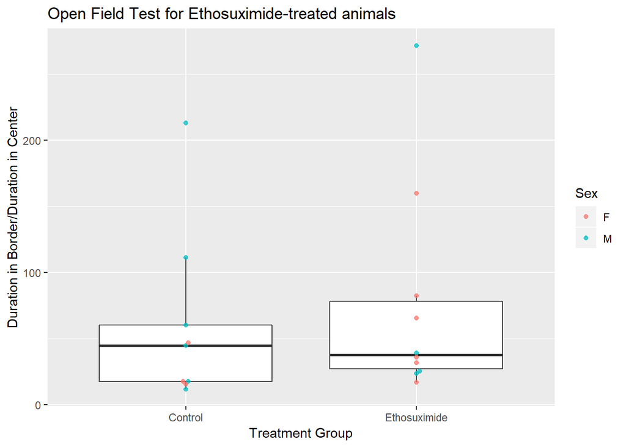

```r
# Plot as a combination of beeswarm and box plot
DurationRatioPlot + geom_boxplot(outlier.alpha = 0) +
    geom_beeswarm(aes(color = Sex), alpha = 0.75)
```

```r
# Save the plot
ggsave("openField_DurationRatio_boxplot_beeswarm.png")
```

## Perform statistics

#### Use Duration in Center

Use the Shapiro-Wilk test to test for normality

```r
# Test the entire data set for normality
shapiro.test(openFieldData$DurationInCenter)
```

```
##
##  Shapiro-Wilk normality test
##
## data:  openFieldData$DurationInCenter
## W = 0.92465, p-value = 0.138
```

```r
# Test each data set for normality
tapply(openFieldData$DurationInCenter, openFieldData$Treatment, shapiro.test)
```

```
## $Control
##
##  Shapiro-Wilk normality test
##
## data:  X[[i]]
## W = 0.89763, p-value = 0.2386
##
##
## $Ethosuximide
##
##  Shapiro-Wilk normality test
##
## data:  X[[i]]
## W = 0.96209, p-value = 0.8094
```

Since the p-values are greater than 0.05, the data sets can be considered normally distributed.

Therefore, we apply the Welch Two Sample t-test to test for any significant difference between treatment groups.

```r
# Apply the Welch Two Sample t-test
tTestResult <-
    t.test(DurationInCenter ~ Treatment, data = openFieldData)
tTestResult
```

```
##
##  Welch Two Sample t-test
##
## data:  DurationInCenter by Treatment
## t = 0.99496, df = 13.189, p-value = 0.3377
## alternative hypothesis: true difference in means is not equal to 0
## 95 percent confidence interval:
##  -7.244599 19.648113
## sample estimates:
##      mean in group Control mean in group Ethosuximide
##                   21.51040                   15.30864
```

Since the p value is greater than 0.05, there isn’t any significant difference between treatment groups.

However, there might be a significant difference between treatment groups when sex is accounted for. Therefore, we can generate a linear model of the duration in center against both treatment group and sex.

```r
# Try modeling the DurationInCenter against Treatment and Sex
openFieldFit <- lm(DurationInCenter ~ Treatment + Sex, data = openFieldData)

# See what the model looks like
summary(openFieldFit)
```

```
##
## Call:
## lm(formula = DurationInCenter ~ Treatment + Sex, data = openFieldData)
##
## Residuals:
##      Min       1Q   Median       3Q      Max
## -17.6126 -10.8705  -0.3397  10.2860  27.0988
##
## Coefficients:
##                       Estimate Std. Error t value Pr(>|t|)
## (Intercept)             23.700      6.235   3.801  0.00157 **
## TreatmentEthosuximide   -7.078      6.454  -1.097  0.28903
## SexM                    -3.285      6.454  -0.509  0.61770
## ---
## Signif. codes:  0 '***' 0.001 '**' 0.01 '*' 0.05 '.' 0.1 ' ' 1
##
## Residual standard error: 13.54 on 16 degrees of freedom
## Multiple R-squared:  0.07263,    Adjusted R-squared:  -0.04329
## F-statistic: 0.6266 on 2 and 16 DF,  p-value: 0.547
```

```r
# In table format
tidy(openFieldFit)
```

```
## # A tibble: 3 x 5
##   term                  estimate std.error statistic p.value
##   <chr>                    <dbl>     <dbl>     <dbl>   <dbl>
## 1 (Intercept)              23.7       6.24     3.80  0.00157
## 2 TreatmentEthosuximide    -7.08      6.45    -1.10  0.289
## 3 SexM                     -3.29      6.45    -0.509 0.618
```

#### Use Ratio of Duration in Border to Duration in Center

Use the Shapiro-Wilk test to test for normality

```r
# Test the entire data set for normality
shapiro.test(openFieldData$DurationRatio)
```

```
##
##  Shapiro-Wilk normality test
##
## data:  openFieldData$DurationRatio
## W = 0.74297, p-value = 0.0001895
```

```r
# Test each data set for normality
tapply(openFieldData$DurationRatio, openFieldData$Treatment, shapiro.test)
```

```
## $Control
##
##  Shapiro-Wilk normality test
##
## data:  X[[i]]
## W = 0.75277, p-value = 0.005838
##
##
## $Ethosuximide
##
##  Shapiro-Wilk normality test
##
## data:  X[[i]]
## W = 0.72768, p-value = 0.00191
```

Since none of the p-values are greater than 0.05, the data sets cannot be considered normally distributed.

Therefore, we apply the Wilcoxon rank-sum test (Mann-Whitney U test) to test for any significant difference between treatment groups.

```r
# Apply the Wilcoxon rank-sum test (Mann-Whitney U test)
wTestResult <-
    wilcox.test(DurationRatio ~ Treatment, data = openFieldData)
wTestResult
```

```
##
##  Wilcoxon rank sum test
##
## data:  DurationRatio by Treatment
## W = 37, p-value = 0.549
## alternative hypothesis: true location shift is not equal to 0
```

Since the p value > 0.05, there isn’t any significant difference between treatment groups.

## Conclusion

There is no significant difference in anxiety between the treatment groups, whether or not sex is accounted for.